# **Introdução**

Dataset do Kaggle. Objetivo é extrair informações relevantes não superficiais.

**Importante** : Em **Análise Exploratória** dos dados contém todos os scripts. Se você tiver conhecimento, fique a vontade para visualizar. Se não, vá direto para **Análise Explanatória**, no qual foca somente em apresentar os insights com uma simples função do código elaborado na EDA (Análise Eploratória de Dados).

## Bibliotecas

```python
import pandas as pd
import seaborn as sns
import matplotlib.pyplot as plt
import numpy as np
```

## Dados

### Customers

```python
dfCustomers = pd.read_csv('data/olist_customers_dataset.csv')
```

```python
dfCustomers.head()
```

|  | customer_id | customer_unique_id | customer_zip_code_prefix | customer_city | customer_state |
| --- | --- | --- | --- | --- | --- |
| 0 | 06b8999e2fba1a1fbc88172c00ba8bc7 | 861eff4711a542e4b93843c6dd7febb0 | 14409 | franca | SP |
| 1 | 18955e83d337fd6b2def6b18a428ac77 | 290c77bc529b7ac935b93aa66c333dc3 | 9790 | sao bernardo do campo | SP |
| 2 | 4e7b3e00288586ebd08712fdd0374a03 | 060e732b5b29e8181a18229c7b0b2b5e | 1151 | sao paulo | SP |
| 3 | b2b6027bc5c5109e529d4dc6358b12c3 | 259dac757896d24d7702b9acbbff3f3c | 8775 | mogi das cruzes | SP |
| 4 | 4f2d8ab171c80ec8364f7c12e35b23ad | 345ecd01c38d18a9036ed96c73b8d066 | 13056 | campinas | SP |

### Gelocation

```python
dfGeolocation = pd.read_csv('data/olist_geolocation_dataset.csv')
dfGeolocation.head(15)
```

|  | geolocation_zip_code_prefix | geolocation_lat | geolocation_lng | geolocation_city | geolocation_state |
| --- | --- | --- | --- | --- | --- |
| 0 | 1037 | -23.545621 | -46.639292 | sao paulo | SP |
| 1 | 1046 | -23.546081 | -46.644820 | sao paulo | SP |
| 2 | 1046 | -23.546129 | -46.642951 | sao paulo | SP |
| 3 | 1041 | -23.544392 | -46.639499 | sao paulo | SP |
| 4 | 1035 | -23.541578 | -46.641607 | sao paulo | SP |
| 5 | 1012 | -23.547762 | -46.635361 | são paulo | SP |
| 6 | 1047 | -23.546273 | -46.641225 | sao paulo | SP |
| 7 | 1013 | -23.546923 | -46.634264 | sao paulo | SP |
| 8 | 1029 | -23.543769 | -46.634278 | sao paulo | SP |
| 9 | 1011 | -23.547640 | -46.636032 | sao paulo | SP |
| 10 | 1013 | -23.547325 | -46.634184 | sao paulo | SP |
| 11 | 1032 | -23.538418 | -46.634778 | sao paulo | SP |
| 12 | 1014 | -23.546435 | -46.633830 | sao paulo | SP |
| 13 | 1012 | -23.548946 | -46.634671 | sao paulo | SP |
| 14 | 1037 | -23.545187 | -46.637855 | são paulo | SP |

### Orders Items

```python
dfOdersItens = pd.read_csv('data/olist_order_items_dataset.csv')
dfOdersItens
```

|  | order_id | order_item_id | product_id | seller_id | shipping_limit_date | price | freight_value |
| --- | --- | --- | --- | --- | --- | --- | --- |
| 0 | 00010242fe8c5a6d1ba2dd792cb16214 | 1 | 4244733e06e7ecb4970a6e2683c13e61 | 48436dade18ac8b2bce089ec2a041202 | 2017-09-19 09:45:35 | 58.90 | 13.29 |
| 1 | 00018f77f2f0320c557190d7a144bdd3 | 1 | e5f2d52b802189ee658865ca93d83a8f | dd7ddc04e1b6c2c614352b383efe2d36 | 2017-05-03 11:05:13 | 239.90 | 19.93 |
| 2 | 000229ec398224ef6ca0657da4fc703e | 1 | c777355d18b72b67abbeef9df44fd0fd | 5b51032eddd242adc84c38acab88f23d | 2018-01-18 14:48:30 | 199.00 | 17.87 |
| 3 | 00024acbcdf0a6daa1e931b038114c75 | 1 | 7634da152a4610f1595efa32f14722fc | 9d7a1d34a5052409006425275ba1c2b4 | 2018-08-15 10:10:18 | 12.99 | 12.79 |
| 4 | 00042b26cf59d7ce69dfabb4e55b4fd9 | 1 | ac6c3623068f30de03045865e4e10089 | df560393f3a51e74553ab94004ba5c87 | 2017-02-13 13:57:51 | 199.90 | 18.14 |
| ... | ... | ... | ... | ... | ... | ... | ... |
| 112645 | fffc94f6ce00a00581880bf54a75a037 | 1 | 4aa6014eceb682077f9dc4bffebc05b0 | b8bc237ba3788b23da09c0f1f3a3288c | 2018-05-02 04:11:01 | 299.99 | 43.41 |
| 112646 | fffcd46ef2263f404302a634eb57f7eb | 1 | 32e07fd915822b0765e448c4dd74c828 | f3c38ab652836d21de61fb8314b69182 | 2018-07-20 04:31:48 | 350.00 | 36.53 |
| 112647 | fffce4705a9662cd70adb13d4a31832d | 1 | 72a30483855e2eafc67aee5dc2560482 | c3cfdc648177fdbbbb35635a37472c53 | 2017-10-30 17:14:25 | 99.90 | 16.95 |
| 112648 | fffe18544ffabc95dfada21779c9644f | 1 | 9c422a519119dcad7575db5af1ba540e | 2b3e4a2a3ea8e01938cabda2a3e5cc79 | 2017-08-21 00:04:32 | 55.99 | 8.72 |
| 112649 | fffe41c64501cc87c801fd61db3f6244 | 1 | 350688d9dc1e75ff97be326363655e01 | f7ccf836d21b2fb1de37564105216cc1 | 2018-06-12 17:10:13 | 43.00 | 12.79 |

112650 rows × 7 columns

### Payment

```python
dfPayment = pd.read_csv('data/olist_order_payments_dataset.csv')
dfPayment.head()
```

|  | order_id | payment_sequential | payment_type | payment_installments | payment_value |
| --- | --- | --- | --- | --- | --- |
| 0 | b81ef226f3fe1789b1e8b2acac839d17 | 1 | credit_card | 8 | 99.33 |
| 1 | a9810da82917af2d9aefd1278f1dcfa0 | 1 | credit_card | 1 | 24.39 |
| 2 | 25e8ea4e93396b6fa0d3dd708e76c1bd | 1 | credit_card | 1 | 65.71 |
| 3 | ba78997921bbcdc1373bb41e913ab953 | 1 | credit_card | 8 | 107.78 |
| 4 | 42fdf880ba16b47b59251dd489d4441a | 1 | credit_card | 2 | 128.45 |

### Reviews

```python
dfReviews = pd.read_csv('data/olist_order_reviews_dataset.csv')
dfReviews
```

|  | review_id | order_id | review_score | review_comment_title | review_comment_message | review_creation_date | review_answer_timestamp |
| --- | --- | --- | --- | --- | --- | --- | --- |
| 0 | 7bc2406110b926393aa56f80a40eba40 | 73fc7af87114b39712e6da79b0a377eb | 4 | NaN | NaN | 2018-01-18 00:00:00 | 2018-01-18 21:46:59 |
| 1 | 80e641a11e56f04c1ad469d5645fdfde | a548910a1c6147796b98fdf73dbeba33 | 5 | NaN | NaN | 2018-03-10 00:00:00 | 2018-03-11 03:05:13 |
| 2 | 228ce5500dc1d8e020d8d1322874b6f0 | f9e4b658b201a9f2ecdecbb34bed034b | 5 | NaN | NaN | 2018-02-17 00:00:00 | 2018-02-18 14:36:24 |
| 3 | e64fb393e7b32834bb789ff8bb30750e | 658677c97b385a9be170737859d3511b | 5 | NaN | Recebi bem antes do prazo estipulado. | 2017-04-21 00:00:00 | 2017-04-21 22:02:06 |
| 4 | f7c4243c7fe1938f181bec41a392bdeb | 8e6bfb81e283fa7e4f11123a3fb894f1 | 5 | NaN | Parabéns lojas lannister adorei comprar pela I... | 2018-03-01 00:00:00 | 2018-03-02 10:26:53 |
| ... | ... | ... | ... | ... | ... | ... | ... |
| 99219 | 574ed12dd733e5fa530cfd4bbf39d7c9 | 2a8c23fee101d4d5662fa670396eb8da | 5 | NaN | NaN | 2018-07-07 00:00:00 | 2018-07-14 17:18:30 |
| 99220 | f3897127253a9592a73be9bdfdf4ed7a | 22ec9f0669f784db00fa86d035cf8602 | 5 | NaN | NaN | 2017-12-09 00:00:00 | 2017-12-11 20:06:42 |
| 99221 | b3de70c89b1510c4cd3d0649fd302472 | 55d4004744368f5571d1f590031933e4 | 5 | NaN | Excelente mochila, entrega super rápida. Super... | 2018-03-22 00:00:00 | 2018-03-23 09:10:43 |
| 99222 | 1adeb9d84d72fe4e337617733eb85149 | 7725825d039fc1f0ceb7635e3f7d9206 | 4 | NaN | NaN | 2018-07-01 00:00:00 | 2018-07-02 12:59:13 |
| 99223 | efe49f1d6f951dd88b51e6ccd4cc548f | 90531360ecb1eec2a1fbb265a0db0508 | 1 | NaN | meu produto chegou e ja tenho que devolver, po... | 2017-07-03 00:00:00 | 2017-07-03 21:01:49 |

99224 rows × 7 columns

### Orders

```python
dfOrders = pd.read_csv('data/olist_orders_dataset.csv')
dfOrders.head()
```

|  | order_id | customer_id | order_status | order_purchase_timestamp | order_approved_at | order_delivered_carrier_date | order_delivered_customer_date | order_estimated_delivery_date |
| --- | --- | --- | --- | --- | --- | --- | --- | --- |
| 0 | e481f51cbdc54678b7cc49136f2d6af7 | 9ef432eb6251297304e76186b10a928d | delivered | 2017-10-02 10:56:33 | 2017-10-02 11:07:15 | 2017-10-04 19:55:00 | 2017-10-10 21:25:13 | 2017-10-18 00:00:00 |
| 1 | 53cdb2fc8bc7dce0b6741e2150273451 | b0830fb4747a6c6d20dea0b8c802d7ef | delivered | 2018-07-24 20:41:37 | 2018-07-26 03:24:27 | 2018-07-26 14:31:00 | 2018-08-07 15:27:45 | 2018-08-13 00:00:00 |
| 2 | 47770eb9100c2d0c44946d9cf07ec65d | 41ce2a54c0b03bf3443c3d931a367089 | delivered | 2018-08-08 08:38:49 | 2018-08-08 08:55:23 | 2018-08-08 13:50:00 | 2018-08-17 18:06:29 | 2018-09-04 00:00:00 |
| 3 | 949d5b44dbf5de918fe9c16f97b45f8a | f88197465ea7920adcdbec7375364d82 | delivered | 2017-11-18 19:28:06 | 2017-11-18 19:45:59 | 2017-11-22 13:39:59 | 2017-12-02 00:28:42 | 2017-12-15 00:00:00 |
| 4 | ad21c59c0840e6cb83a9ceb5573f8159 | 8ab97904e6daea8866dbdbc4fb7aad2c | delivered | 2018-02-13 21:18:39 | 2018-02-13 22:20:29 | 2018-02-14 19:46:34 | 2018-02-16 18:17:02 | 2018-02-26 00:00:00 |

### Products

```python
dfProducts = pd.read_csv('data/olist_products_dataset.csv')
dfProducts
```

|  | product_id | product_category_name | product_name_lenght | product_description_lenght | product_photos_qty | product_weight_g | product_length_cm | product_height_cm | product_width_cm |
| --- | --- | --- | --- | --- | --- | --- | --- | --- | --- |
| 0 | 1e9e8ef04dbcff4541ed26657ea517e5 | perfumaria | 40.0 | 287.0 | 1.0 | 225.0 | 16.0 | 10.0 | 14.0 |
| 1 | 3aa071139cb16b67ca9e5dea641aaa2f | artes | 44.0 | 276.0 | 1.0 | 1000.0 | 30.0 | 18.0 | 20.0 |
| 2 | 96bd76ec8810374ed1b65e291975717f | esporte_lazer | 46.0 | 250.0 | 1.0 | 154.0 | 18.0 | 9.0 | 15.0 |
| 3 | cef67bcfe19066a932b7673e239eb23d | bebes | 27.0 | 261.0 | 1.0 | 371.0 | 26.0 | 4.0 | 26.0 |
| 4 | 9dc1a7de274444849c219cff195d0b71 | utilidades_domesticas | 37.0 | 402.0 | 4.0 | 625.0 | 20.0 | 17.0 | 13.0 |
| ... | ... | ... | ... | ... | ... | ... | ... | ... | ... |
| 32946 | a0b7d5a992ccda646f2d34e418fff5a0 | moveis_decoracao | 45.0 | 67.0 | 2.0 | 12300.0 | 40.0 | 40.0 | 40.0 |
| 32947 | bf4538d88321d0fd4412a93c974510e6 | construcao_ferramentas_iluminacao | 41.0 | 971.0 | 1.0 | 1700.0 | 16.0 | 19.0 | 16.0 |
| 32948 | 9a7c6041fa9592d9d9ef6cfe62a71f8c | cama_mesa_banho | 50.0 | 799.0 | 1.0 | 1400.0 | 27.0 | 7.0 | 27.0 |
| 32949 | 83808703fc0706a22e264b9d75f04a2e | informatica_acessorios | 60.0 | 156.0 | 2.0 | 700.0 | 31.0 | 13.0 | 20.0 |
| 32950 | 106392145fca363410d287a815be6de4 | cama_mesa_banho | 58.0 | 309.0 | 1.0 | 2083.0 | 12.0 | 2.0 | 7.0 |

32951 rows × 9 columns

### Sellers

```python
dfSellers = pd.read_csv('data/olist_sellers_dataset.csv')
dfSellers
```

|  | seller_id | seller_zip_code_prefix | seller_city | seller_state |
| --- | --- | --- | --- | --- |
| 0 | 3442f8959a84dea7ee197c632cb2df15 | 13023 | campinas | SP |
| 1 | d1b65fc7debc3361ea86b5f14c68d2e2 | 13844 | mogi guacu | SP |
| 2 | ce3ad9de960102d0677a81f5d0bb7b2d | 20031 | rio de janeiro | RJ |
| 3 | c0f3eea2e14555b6faeea3dd58c1b1c3 | 4195 | sao paulo | SP |
| 4 | 51a04a8a6bdcb23deccc82b0b80742cf | 12914 | braganca paulista | SP |
| ... | ... | ... | ... | ... |
| 3090 | 98dddbc4601dd4443ca174359b237166 | 87111 | sarandi | PR |
| 3091 | f8201cab383e484733266d1906e2fdfa | 88137 | palhoca | SC |
| 3092 | 74871d19219c7d518d0090283e03c137 | 4650 | sao paulo | SP |
| 3093 | e603cf3fec55f8697c9059638d6c8eb5 | 96080 | pelotas | RS |
| 3094 | 9e25199f6ef7e7c347120ff175652c3b | 12051 | taubate | SP |

3095 rows × 4 columns

### Category

```python
dfCategory = pd.read_csv('data/product_category_name_translation.csv')
dfCategory
```

|  | product_category_name | product_category_name_english |
| --- | --- | --- |
| 0 | beleza_saude | health_beauty |
| 1 | informatica_acessorios | computers_accessories |
| 2 | automotivo | auto |
| 3 | cama_mesa_banho | bed_bath_table |
| 4 | moveis_decoracao | furniture_decor |
| ... | ... | ... |
| 66 | flores | flowers |
| 67 | artes_e_artesanato | arts_and_craftmanship |
| 68 | fraldas_higiene | diapers_and_hygiene |
| 69 | fashion_roupa_infanto_juvenil | fashion_childrens_clothes |
| 70 | seguros_e_servicos | security_and_services |

71 rows × 2 columns

# Análise Exploratória dos dados

### Análise entre preço e frete

- Quanto mais caro o produto mais caro o frete?

```python
dfProductsMerge = pd.merge(dfProducts, dfOdersItens, how='inner', on='product_id')
dfProductsMerge.head()
```

|  | product_id | product_category_name | product_name_lenght | product_description_lenght | product_photos_qty | product_weight_g | product_length_cm | product_height_cm | product_width_cm | order_id | order_item_id | seller_id | shipping_limit_date | price | freight_value |
| --- | --- | --- | --- | --- | --- | --- | --- | --- | --- | --- | --- | --- | --- | --- | --- |
| 0 | 1e9e8ef04dbcff4541ed26657ea517e5 | perfumaria | 40.0 | 287.0 | 1.0 | 225.0 | 16.0 | 10.0 | 14.0 | e17e4f88e31525f7deef66779844ddce | 1 | 5670f4db5b62c43d542e1b2d56b0cf7c | 2018-04-30 17:33:54 | 10.91 | 7.39 |
| 1 | 3aa071139cb16b67ca9e5dea641aaa2f | artes | 44.0 | 276.0 | 1.0 | 1000.0 | 30.0 | 18.0 | 20.0 | 5236307716393b7114b53ee991f36956 | 1 | b561927807645834b59ef0d16ba55a24 | 2018-02-06 19:11:15 | 248.00 | 17.99 |
| 2 | 96bd76ec8810374ed1b65e291975717f | esporte_lazer | 46.0 | 250.0 | 1.0 | 154.0 | 18.0 | 9.0 | 15.0 | 01f66e58769f84129811d43eefd187fb | 1 | 7b07b3c7487f0ea825fc6df75abd658b | 2018-07-11 21:30:20 | 79.80 | 7.82 |
| 3 | cef67bcfe19066a932b7673e239eb23d | bebes | 27.0 | 261.0 | 1.0 | 371.0 | 26.0 | 4.0 | 26.0 | 143d00a4f2dde4e0364ee1821577adb3 | 1 | c510bc1718f0f2961eaa42a23330681a | 2018-08-07 09:10:13 | 112.30 | 9.54 |
| 4 | 9dc1a7de274444849c219cff195d0b71 | utilidades_domesticas | 37.0 | 402.0 | 4.0 | 625.0 | 20.0 | 17.0 | 13.0 | 86cafb8794cb99a9b1b77fc8e48fbbbb | 1 | 0be8ff43f22e456b4e0371b2245e4d01 | 2018-04-17 01:30:23 | 37.90 | 8.29 |

```python
dfOdersItens.head()
```

|  | order_id | order_item_id | product_id | seller_id | shipping_limit_date | price | freight_value |
| --- | --- | --- | --- | --- | --- | --- | --- |
| 0 | 00010242fe8c5a6d1ba2dd792cb16214 | 1 | 4244733e06e7ecb4970a6e2683c13e61 | 48436dade18ac8b2bce089ec2a041202 | 2017-09-19 09:45:35 | 58.90 | 13.29 |
| 1 | 00018f77f2f0320c557190d7a144bdd3 | 1 | e5f2d52b802189ee658865ca93d83a8f | dd7ddc04e1b6c2c614352b383efe2d36 | 2017-05-03 11:05:13 | 239.90 | 19.93 |
| 2 | 000229ec398224ef6ca0657da4fc703e | 1 | c777355d18b72b67abbeef9df44fd0fd | 5b51032eddd242adc84c38acab88f23d | 2018-01-18 14:48:30 | 199.00 | 17.87 |
| 3 | 00024acbcdf0a6daa1e931b038114c75 | 1 | 7634da152a4610f1595efa32f14722fc | 9d7a1d34a5052409006425275ba1c2b4 | 2018-08-15 10:10:18 | 12.99 | 12.79 |
| 4 | 00042b26cf59d7ce69dfabb4e55b4fd9 | 1 | ac6c3623068f30de03045865e4e10089 | df560393f3a51e74553ab94004ba5c87 | 2017-02-13 13:57:51 | 199.90 | 18.14 |

```python
dfOdersItens[['price', 'freight_value']].corr()
```

|  | price | freight_value |
| --- | --- | --- |
| price | 1.000000 | 0.414204 |
| freight_value | 0.414204 | 1.000000 |

```python
dfOdersItens[['price', 'freight_value']]
```

|  | price | freight_value |
| --- | --- | --- |
| 0 | 58.90 | 13.29 |
| 1 | 239.90 | 19.93 |
| 2 | 199.00 | 17.87 |
| 3 | 12.99 | 12.79 |
| 4 | 199.90 | 18.14 |
| ... | ... | ... |
| 112645 | 299.99 | 43.41 |
| 112646 | 350.00 | 36.53 |
| 112647 | 99.90 | 16.95 |
| 112648 | 55.99 | 8.72 |
| 112649 | 43.00 | 12.79 |

112650 rows × 2 columns

```python
def cor():
    plt.figure(figsize = (8,6))
    ax = sns.heatmap(dfOdersItens[['price', 'freight_value']].corr(), annot=True)
    ax.set_title('Correlação entre preço e frete', fontsize =18, loc = 'left')
    plt.show()
```

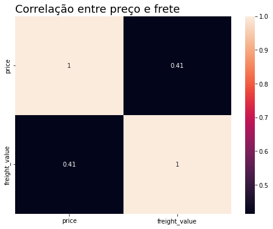

```python
cor()
```

```python
def weight():
    plt.figure(figsize = (8,6))
    ax = sns.heatmap(dfProductsMerge[['product_weight_g', 'freight_value']].corr(), annot=True)
    ax.set_title('Correlação entre peso e frete', fontsize =18, loc = 'left')
    plt.show()
```

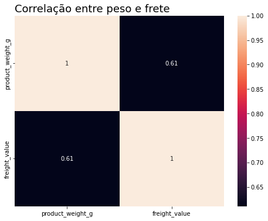

```python
weight()
```

### Qual produto tem o maior frete?

```python
a = dfProductsMerge.groupby(['product_category_name']).mean()[['freight_value']].sort_values(by='freight_value', ascending=False)
a.head()
```

| product_category_name | freight_value |
| --- | --- |
| pcs | 48.454680 |
| eletrodomesticos_2 | 44.538571 |
| moveis_colchao_e_estofado | 42.906842 |
| moveis_cozinha_area_de_servico_jantar_e_jardim | 42.702598 |
| moveis_quarto | 42.497523 |

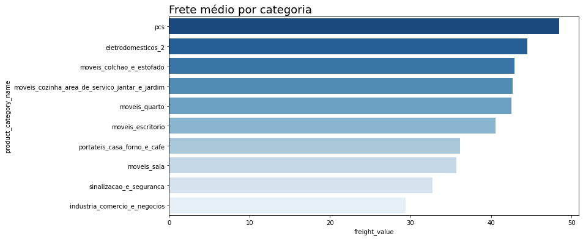

```python
def freight():
    plt.figure(figsize = (12,6))
    ax = sns.barplot(data = a[:10], x = 'freight_value', y = a[:10].index, palette='Blues_r')
    ax.set_title('Frete médio por categoria', fontsize =18, loc = 'left')
freight()
```

```python
dfProductsMerge.groupby(['product_category_name']).median()[['freight_value']].sort_values(by='freight_value', ascending=False)
```

| product_category_name | freight_value |
| --- | --- |
| pcs | 41.550 |
| moveis_colchao_e_estofado | 38.970 |
| moveis_quarto | 38.110 |
| eletrodomesticos_2 | 36.230 |
| moveis_escritorio | 34.180 |
| ... | ... |
| fraldas_higiene | 12.920 |
| artes_e_artesanato | 12.865 |
| fashion_roupa_feminina | 12.800 |
| fashion_roupa_infanto_juvenil | 12.125 |
| livros_importados | 10.030 |

73 rows × 1 columns

```python
dfPcs = dfProductsMerge.query('product_category_name == "pcs"')
def regfreight():
    ax = sns.lmplot(x = 'price', y = 'freight_value', data = dfPcs)
    ax.fig.suptitle('Regressão entre preço e frete', fontsize =18, x = 0.21, y = 1.1)
    ax.figure.set_size_inches(12,8)
    plt.show()
```

```python
def freq():
    plt.figure(figsize = (12,8))
    ax = sns.histplot(dfPcs['freight_value'], kde=True)
    ax.set_title('Distribuição do frete para produtos da categoria pcs', fontsize =18, x = 0.25, y = 1.1)
    plt.show()
```

```python
dfPcs.describe()
```

|  | product_name_lenght | product_description_lenght | product_photos_qty | product_weight_g | product_length_cm | product_height_cm | product_width_cm | order_item_id | price | freight_value |
| --- | --- | --- | --- | --- | --- | --- | --- | --- | --- | --- |
| count | 203.000000 | 203.000000 | 203.000000 | 203.000000 | 203.000000 | 203.000000 | 203.000000 | 203.000000 | 203.000000 | 203.000000 |
| mean | 55.576355 | 2602.344828 | 2.857143 | 7216.798030 | 26.211823 | 37.014778 | 41.669951 | 1.157635 | 1098.340542 | 48.454680 |
| std | 1.949316 | 1207.014351 | 1.467228 | 5513.193814 | 13.584698 | 12.460026 | 8.838173 | 0.482135 | 668.513798 | 24.801105 |
| min | 44.000000 | 451.000000 | 1.000000 | 200.000000 | 16.000000 | 6.000000 | 16.000000 | 1.000000 | 34.500000 | 15.090000 |
| 25% | 55.000000 | 1105.000000 | 1.000000 | 2600.000000 | 16.000000 | 31.000000 | 39.000000 | 1.000000 | 650.000000 | 33.200000 |
| 50% | 55.000000 | 3610.000000 | 4.000000 | 2800.000000 | 16.000000 | 31.000000 | 39.000000 | 1.000000 | 1100.000000 | 41.550000 |
| 75% | 55.000000 | 3632.000000 | 4.000000 | 12600.000000 | 28.000000 | 50.000000 | 52.000000 | 1.000000 | 1340.000000 | 55.410000 |
| max | 63.000000 | 3913.000000 | 7.000000 | 25950.000000 | 54.000000 | 95.000000 | 54.000000 | 4.000000 | 6729.000000 | 193.210000 |

### Qual categoria de produto tem o preço maior?

```python
dfProductPrice = dfProductsMerge.groupby('product_category_name', as_index=False)['price'].mean()
dfProductPrice = pd.DataFrame(dfProductPrice)
dfProductPrice.head()
```

|  | product_category_name | price |
| --- | --- | --- |
| 0 | agro_industria_e_comercio | 342.124858 |
| 1 | alimentos | 57.634137 |
| 2 | alimentos_bebidas | 54.602446 |
| 3 | artes | 115.802105 |
| 4 | artes_e_artesanato | 75.583750 |

```python
dfProductPrice = dfProductPrice.sort_values('price', ascending=False)
dfProductPrice
```

|  | product_category_name | price |
| --- | --- | --- |
| 61 | pcs | 1098.340542 |
| 64 | portateis_casa_forno_e_cafe | 624.285658 |
| 29 | eletrodomesticos_2 | 476.124958 |
| 0 | agro_industria_e_comercio | 342.124858 |
| 45 | instrumentos_musicais | 281.616000 |
| ... | ... | ... |
| 2 | alimentos_bebidas | 54.602446 |
| 17 | cds_dvds_musicais | 52.142857 |
| 42 | fraldas_higiene | 40.194615 |
| 41 | flores | 33.637576 |
| 15 | casa_conforto_2 | 25.342333 |

73 rows × 2 columns

#### 10 produtos mais caros (em média)

```python
df10Products = dfProductPrice.iloc[0:10]
df10Products
```

|  | product_category_name | price |
| --- | --- | --- |
| 61 | pcs | 1098.340542 |
| 64 | portateis_casa_forno_e_cafe | 624.285658 |
| 29 | eletrodomesticos_2 | 476.124958 |
| 0 | agro_industria_e_comercio | 342.124858 |
| 45 | instrumentos_musicais | 281.616000 |
| 31 | eletroportateis | 280.778468 |
| 65 | portateis_cozinha_e_preparadores_de_alimentos | 264.568667 |
| 71 | telefonia_fixa | 225.693182 |
| 25 | construcao_ferramentas_seguranca | 208.992371 |
| 66 | relogios_presentes | 201.135984 |

```python
df10Products
```

|  | product_category_name | price |
| --- | --- | --- |
| 61 | pcs | 1098.340542 |
| 64 | portateis_casa_forno_e_cafe | 624.285658 |
| 29 | eletrodomesticos_2 | 476.124958 |
| 0 | agro_industria_e_comercio | 342.124858 |
| 45 | instrumentos_musicais | 281.616000 |
| 31 | eletroportateis | 280.778468 |
| 65 | portateis_cozinha_e_preparadores_de_alimentos | 264.568667 |
| 71 | telefonia_fixa | 225.693182 |
| 25 | construcao_ferramentas_seguranca | 208.992371 |
| 66 | relogios_presentes | 201.135984 |

```python
import matplotlib.pyplot as plt
```

```python
sns.set_palette('Blues_r')
sns.set_style('ticks')
```

```python
def graphproducts ():
  plt.figure(figsize = (12, 8))
  ax = sns.barplot(x = 'product_category_name', y = 'price', data = df10Products,
                  order = df10Products.sort_values('price', ascending = False).product_category_name,
                  palette='Blues_r')
  plt.xticks(rotation = 90)
  ax.set_title("Análise das 10 categorias de produtos mais caros", fontsize = 18, loc = 'left')
  ax.set_ylabel("Preços")
  ax.set_xlabel("Categoria", fontsize = 12 )
  for i in ax.containers:
        ax.bar_label(i,)
  plt.show()
```

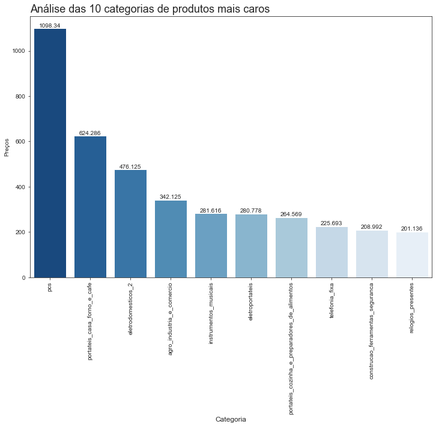

```python
graphproducts()
```

```python
dfProductPrice.describe()
```

|  | price |
| --- | --- |
| count | 73.000000 |
| mean | 146.789532 |
| std | 146.186357 |
| min | 25.342333 |
| 25% | 81.801667 |
| 50% | 114.949474 |
| 75% | 154.407282 |
| max | 1098.340542 |

**Insight 1 : A categoria pcs tem a maior média dos preços. Ou seja, produtos mais caros. (Em média)**

```python
dfpcs= dfProductsMerge.loc[dfProductsMerge.product_category_name == 'pcs']
dfpcs.head()
```

|  | product_id | product_category_name | product_name_lenght | product_description_lenght | product_photos_qty | product_weight_g | product_length_cm | product_height_cm | product_width_cm | order_id | order_item_id | seller_id | shipping_limit_date | price | freight_value |
| --- | --- | --- | --- | --- | --- | --- | --- | --- | --- | --- | --- | --- | --- | --- | --- |
| 185 | 1e5428c428e0f783acd6e3d94ba4ee2a | pcs | 55.0 | 1067.0 | 1.0 | 12000.0 | 27.0 | 50.0 | 53.0 | 17774450f243f686546b04633a04dbdb | 1 | 53243585a1d6dc2643021fd1853d8905 | 2017-12-21 01:17:24 | 599.0 | 67.68 |
| 186 | 1e5428c428e0f783acd6e3d94ba4ee2a | pcs | 55.0 | 1067.0 | 1.0 | 12000.0 | 27.0 | 50.0 | 53.0 | 5383435eb2b05b6f4d5be7720974fe67 | 1 | 53243585a1d6dc2643021fd1853d8905 | 2017-12-26 09:59:40 | 599.0 | 73.41 |
| 187 | 1e5428c428e0f783acd6e3d94ba4ee2a | pcs | 55.0 | 1067.0 | 1.0 | 12000.0 | 27.0 | 50.0 | 53.0 | 63a2ef605ed6a193d40b312ca1b014d5 | 1 | 53243585a1d6dc2643021fd1853d8905 | 2017-12-19 21:10:46 | 599.0 | 58.63 |
| 188 | 1e5428c428e0f783acd6e3d94ba4ee2a | pcs | 55.0 | 1067.0 | 1.0 | 12000.0 | 27.0 | 50.0 | 53.0 | 85ead861d8aad2f8734d85d187a42b7f | 1 | 53243585a1d6dc2643021fd1853d8905 | 2017-12-15 18:15:25 | 599.0 | 55.41 |
| 189 | 1e5428c428e0f783acd6e3d94ba4ee2a | pcs | 55.0 | 1067.0 | 1.0 | 12000.0 | 27.0 | 50.0 | 53.0 | a23f4025d60af6199b5eb5631b070e7f | 1 | 53243585a1d6dc2643021fd1853d8905 | 2017-12-14 16:31:19 | 599.0 | 32.47 |

```python
pd.DataFrame(dfpcs['price'].agg(['mean', 'max', 'min']))
```

|  | price |
| --- | --- |
| mean | 1098.340542 |
| max | 6729.000000 |
| min | 34.500000 |